# Troubleshooting and Learning New Things in R

```r
library(tidyverse)
library(ggeasy)
```

# Errors installing new package…what do you do when you encounter errors?

[installing packages blog](https://www.littlemissdata.com/blog/r-package-install)

- we want to install the “emo” packages
- we found that install.packages(“emo”) didn’t work and resulted in an error…why??!!
- packages may or may not exist on CRAN, but install.packages() will only work for packages that exist on CRAN
- so if you search for a package on CRAN and it’s not there what should you do? …I’d do a Google search for “install package X in R”
- I often find that if packages aren’t on CRAN they are on github, so you can locate the repository and install the package via devtools
- you’ll need to install devtools if it’s not already installed
- make sure to restart your R session after installing devtools
- also make sure to loab it in library(devtools)
- there’s an install_github function to install R packages hosted on GitHub in the devtools package
- install_github(“DeveloperName/PackageName”)

```r
# commented out how to uninstall packages:

# library(installr)
# uninstall.packages("emo")

install.packages("emo")

install.packages("devtools")

# you can either run one line altogether like this:
devtools::install_github("hadley/emo")

# or you can run two lines like this:
library(devtools)
install_github("hadley/emo")
```

```r
library(emo)
emo::ji("smile")
```

# Learning Something New

## Cheatsheets

- [ggplot2 cheatsheet](https://www.rstudio.com/wp-content/uploads/2015/03/ggplot2-cheatsheet.pdf)
- [rmarkdown cheatsheet](https://www.rstudio.com/wp-content/uploads/2015/02/rmarkdown-cheatsheet.pdf)

## tutorials

- [r4ds](https://r4ds.had.co.nz/)
- [RYouWithMe](https://rladiessydney.org/courses/ryouwithme/)

## blog posts

- [Alison Hill Blogdown Blog](https://alison.rbind.io/post/2017-06-12-up-and-running-with-blogdown/)
- [purrr](http://www.rebeccabarter.com/blog/2019-08-19_purrr/)

# How to choose where to start???

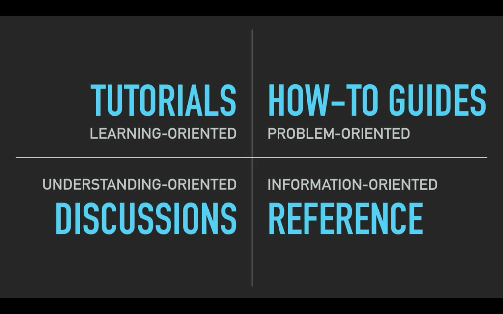

Where to Start 2

- if you’re just looking to new things in general then tutorials are a great option because they’ll cover a range of topics
- however, if you have a specific problem then blog posts are often a better place to start because they will walk you through how to use a given package
- tip from Jenny R: when she is trying to learn something new, she’ll Google “how to do X in R blog”
- if you’ve used a package before, but can’t remember the arguments or just want to see one quick example then start with the R documentation (often there will be examples at the bottom of the documentation)